# Detecting deforestation in the Brazilian Amazon

Comparing the NDVI to the woodiness index

Jannis Fröhlking (439 599)

March 23rd, 2021

# 1 Introduction

Climate change is one of the world’s most pressing problems (Cabrera et al. 2008). If governments continue current policies, researchers predict a 50% chance of exceeding a rise of 3.2 °C by 2100 compared to pre-industrial levels (1850-1900) and a 10% chance of exceeding a rise of 4.4°C by 2100 (Rogelj et al. 2016). There are several risks that temperature increases involve ranging from health factors like heat stress to environmental factors. These are risk of crop failures, water shortages, droughts, the risk of river flooding and the sea-level rise concerning coastal cities (King et al. 2017).

The Amazon rainforest is largely impacted by the climate change. Simulating the raising CO2 levels projects a 70% loss of the Amazon rainforest area by the end of the 21st century (Cook and Vizy 2008). This simulation does not include human and agricultural activity, which will further shrink its size. It is important to note that the dieback of the Amazon rainforest is one of the tipping elements, which describe Earth systems that can be changed to a significantly different state by little disturbances (Lenton et al. 2008). In a row with the melting of the Greenland ice sheet or the El Nino – Southern Oscillation (ENSO) it is one of the most climate sensitive subsystems of the Earth (Lenton et al. 2008).

The Amazon rainforest recycles tons of precipitation and plays a crucial role for the atmospheric moisture supply (King et al. 2017). Zeng et al. predicted that deforestation of the Amazon would lead to a 20% - 30% decrease of precipitation (Zeng, Dickinson, and Zeng 1996). The loss of moisture would harm every country in South America except Chile (blocked by the Andes) and would yield to an increase of tropical savannahs (Lovejoy and Nobre 2019). Apart from rainfall decrease the biodiversity loss in the Amazon rainforest is a crucial result of deforestation, because about 75% of the world’s terrestrial species live there (Lenton et al. 2008; Malhi et al. 2008).

Since 1970 the Brazilian Amazon lost more than 700.000 km² of forest which is 82.7% of its original extent (Butler, n.d.). Manmade clearance is driven by the need for agricultural land to produce soybean and farming of cattle (Malhi et al. 2008). However, the logging, hunting and fire leakage activities are often illegal and need to be monitored to combat deforestation. Near-real-time forest loss detection systems started as the well-known systems DETER and SAD in the early 2000s using coarse resolution MODIS imagery (Finer et al. 2018). The advent of medium-resolution Landsat and Sentinel imagery improved the forest loss detections. Research proved that timely identification of deforestation drivers by remotes sensing based monitoring has reduced the deforestation (Finer et al. 2018).

Nonetheless, detecting deforestation can be further optimized to give more accurate predictions. The two main approaches to detect forest degradation are first based on the change of canopy cover allowing for clear cut identifications and second the quantification of biomass loss (Mitchell, Rosenqvist, and Mora 2017). For each approach, many different methods can be used dealing with either multi-resolution optical, synthetic aperture radar (SAR), LiDAR data or EO sensors. One of the most used indices to classify forest images is the „Normalized Difference Vegetation Index“(NDVI) (de Vries et al. 2013; Spruce et al. 2011; Hojas-Gascon et al. 2015). This report wants to compare classification results based on the NDVI with results based on the simple woodiness index. The woodiness index is a more unknown indices developed by Lehmann et al. (2013) to provide visual indication of within-forest vegetation changes. In its simple version it is the inverted combination of the visible green and the near-infrared band and it is positively correlated with vegetation density(Lehmann et al. 2013).

# 2 Data

The analysis is based on surface reflectance products from the Landsat 8 product provided by the United States Geological survey (USGS). The image series covers the temporal range from 19th April 2013 to 07th November 2019 in a 16-day cycle and has a resolution of 30 meters. The images can be downloaded from [sciebo](https://uni-muenster.sciebo.de/s/yvFiuWGqG7riliA/download). The research area lies in the northwest of Brazil, in the south of the Amazonas state. It borders on the Brazilian state Rondônia in the south east and on Bolivia in the south.

[interactive chart not shown]

# 3 Methods

The main part of the analysis was done in R (R Core Team 2020). The code is based on course material for “Analyzing Spatio-Temporal Data” (Pebesma 2021c, 2021a). In a first step the images were aggregated to median values of a spatial resolution of 500 meter and a temporal resolution of one year using the *gdalcubes* package (Appel and Pebesma 2019). These data cubes convert satellite images to analysis-ready data by hiding complexities and supporting interactivity. Apart from NDVI and woodiness data cubes, true-color composites were built to allow for a visual interpretation of the forest. These data cubes were further processed as spatiotemporal arrays by the *stars* package (Pebesma 2021b).

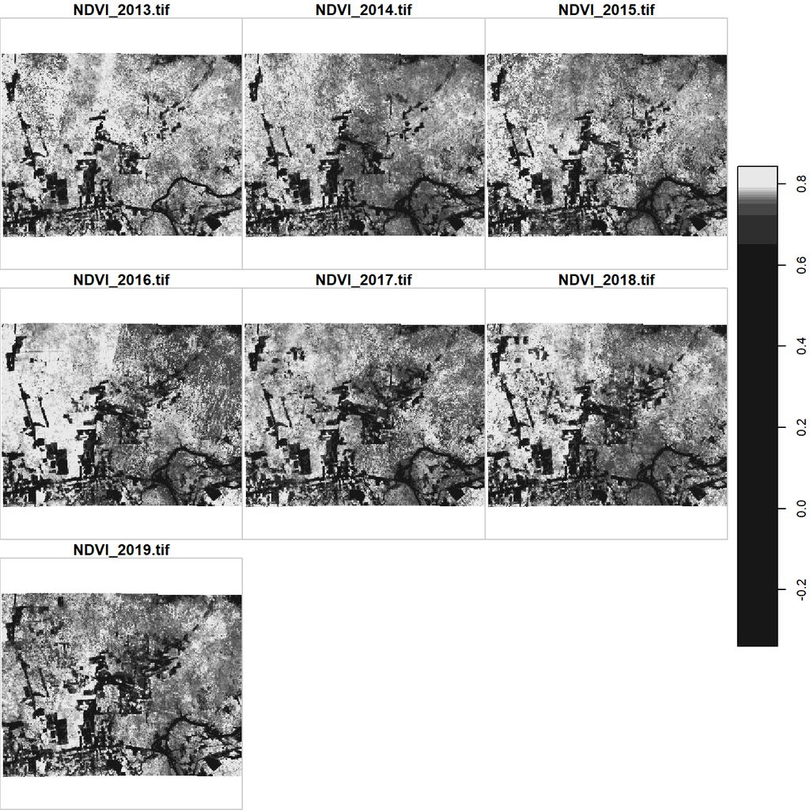

*Figure 1. Aggregated NDVI images*

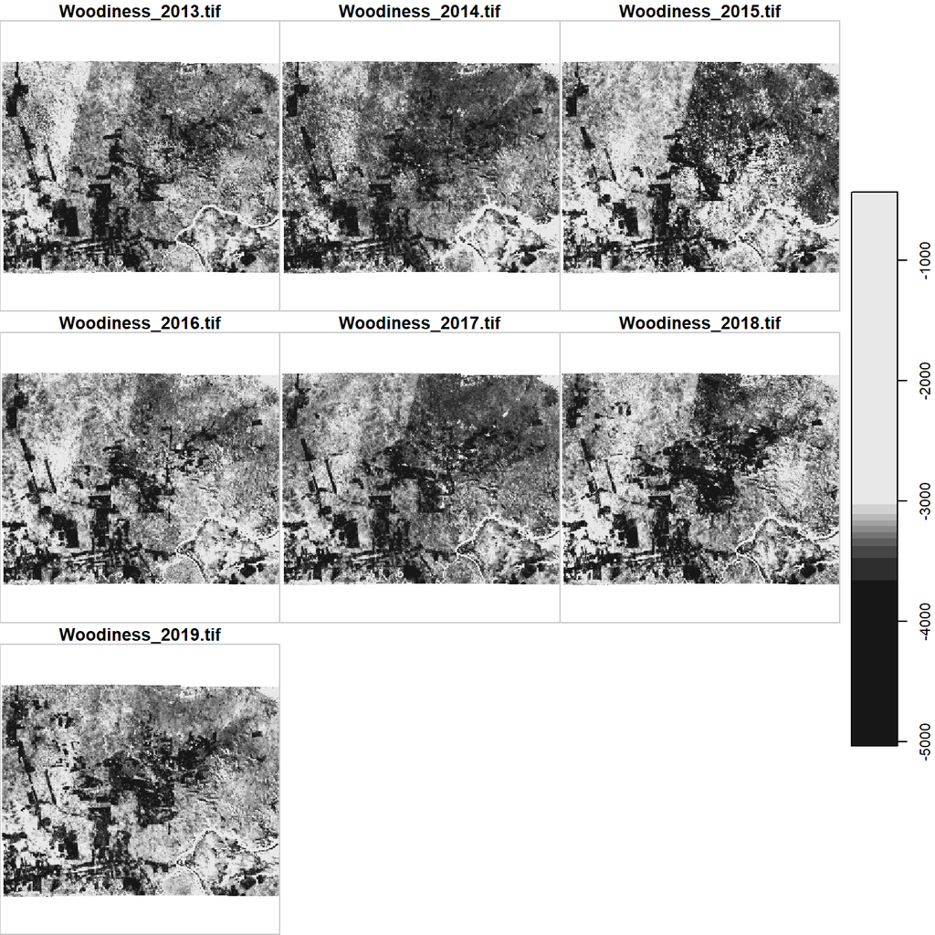

*Figure 2. Aggregated woodiness images*

A major issue by using satellite images are pixels covered by clouds. Due to the aggregation to one-year images many NA values were already removed. However, there are still cloud pixels without values. To tackle that issue the missing values were approximated by interpolating with the temporally nearest available values.

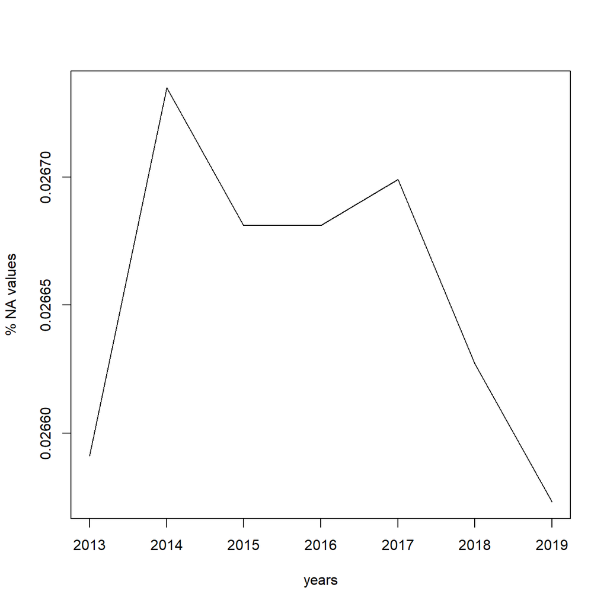

*Figure 3. Amount of NA values per image*

In the next step reference data was collected to prepare a supervised classification. Therefore, based on visual interpretation a shapefile including polygons assigned either as forest or non-forest area was created using the geographic information system QGIS (QGIS Development Team 2021). The reference data was collected from the first aggregated image in 2013. The polygons were used to extract the related NDVI/woodiness values. On the training data set with the predictor variable NDVI/woodiness and the outcome variable specifying if it is forest, the two models were built. Here the well-known random forest method was used combined with a Leave-Location-Out spatial cross validation. The target-oriented validation strategy decreases overfitting and improves model performance (Meyer 2021).

Based on the two models the spatio-temporal arrays were classified in forest/non-forest pixels. Identification of deforestation was achieved by comparing two consecutive images. If an image pixel was classified as forest at timestep t-1 and classified as non-forest at timestep t, it is considered deforested.

The two models were compared by using the *Cohen’s Kappa*, which is a statistical measure for categorical variables which takes the agreement occurring by chance into account (Cohen 1960).

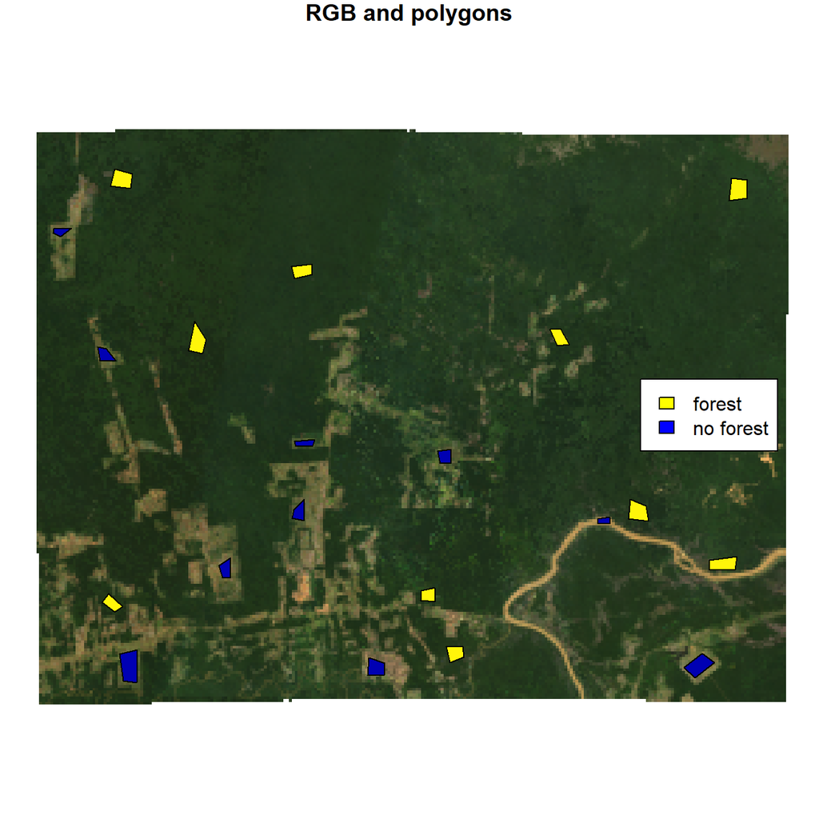

*Figure 4. Reference data*

# 4 Results

Many NA values were removed by the temporal interpolation. Because the temporal approximation is not able to predict leading or trailing images, there is a little amount of NA values for these images left.

The model based on the NDVI scores a Kappa of 0.80 which is according to Landis and Koch (1977) an almost perfect agreement. The model based on the woodiness index has a moderate agreement with a Kappa of 0.55 (Landis and Koch 1977).

```
## [1] "Kappa of NDVI model: 0.800000"
```

```
## [1] "Kappa of Woodiness model: 0.552566"
```

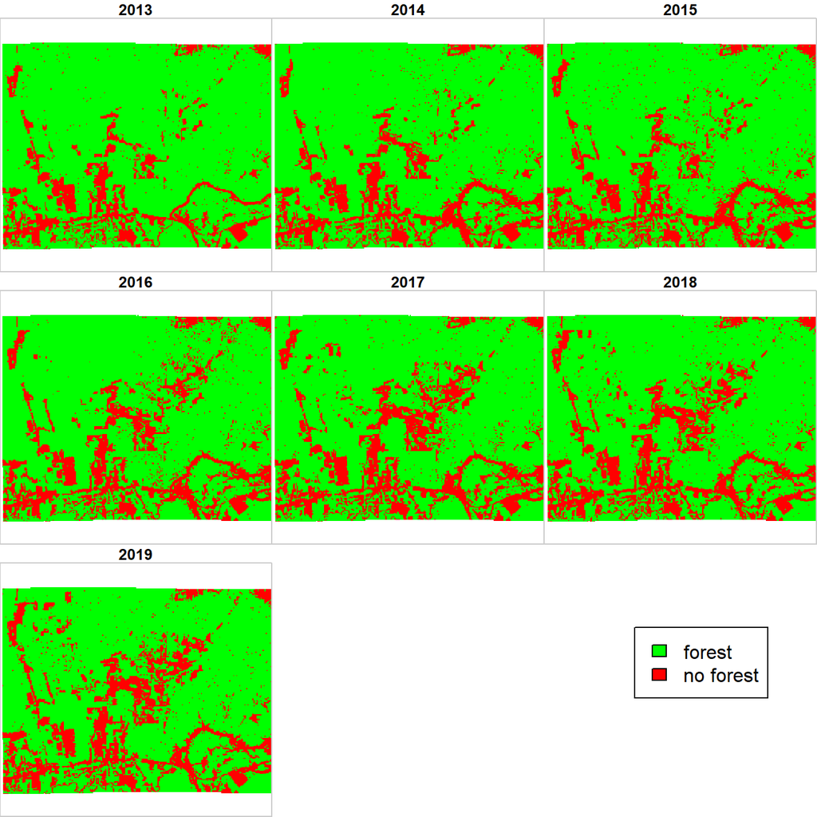

*Figure 5. Classification based on NDVI*

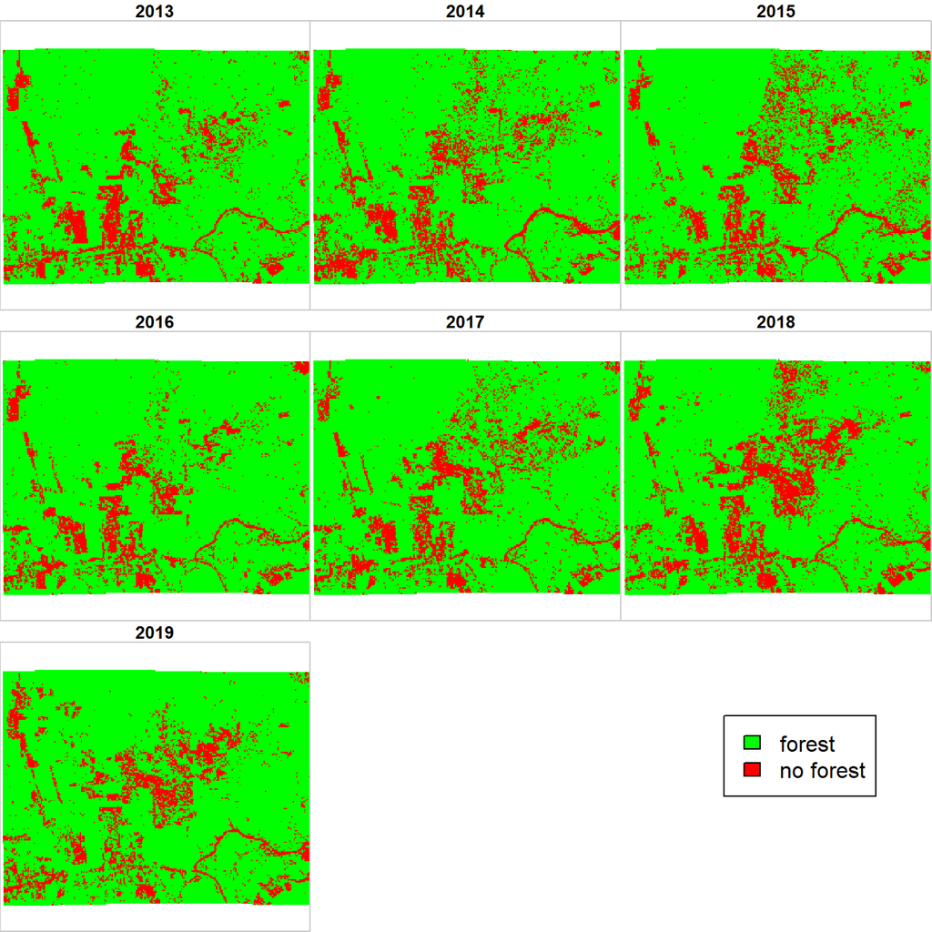

*Figure 6. Classification based on Woodiness*

Identification of classification differences can be done by switch the following layers on and off (here based on the 2019 image):

[interactive chart not shown]

The resulting time series predictions show the change from forest to non-forest for each year.

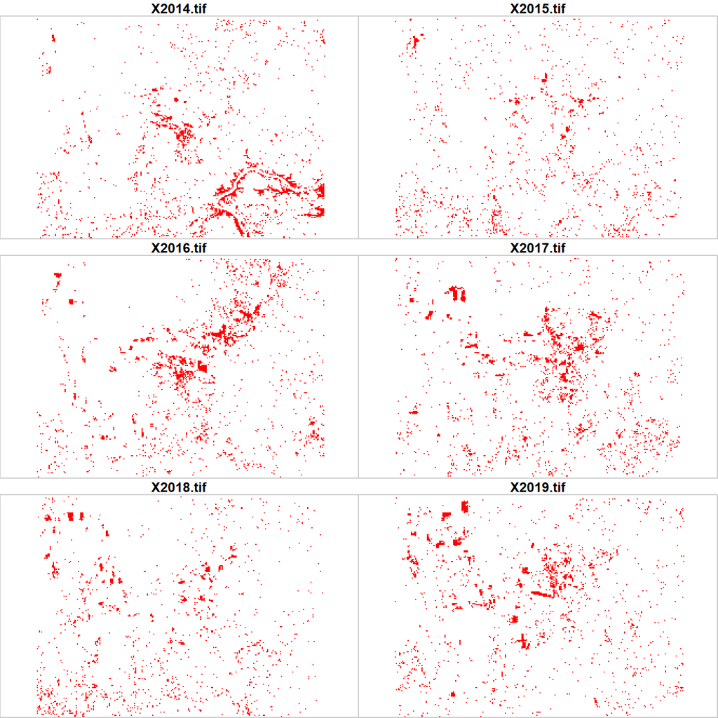

*Figure 8. Modelled deforestation based on NDVI*

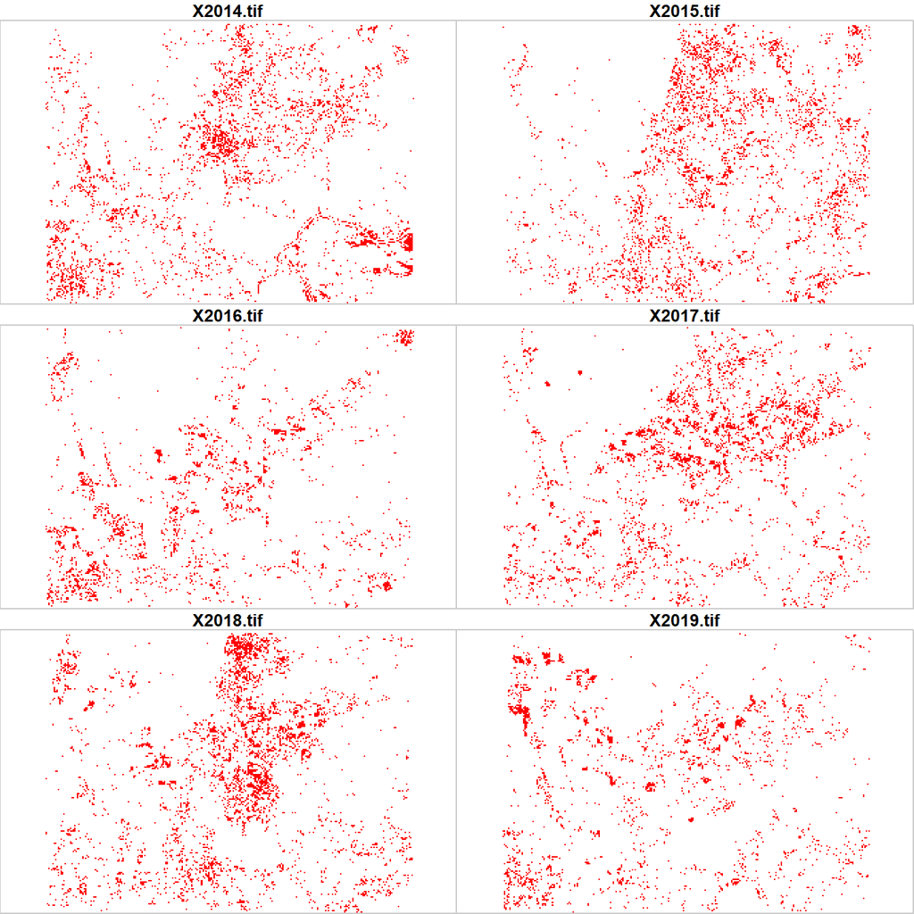

*Figure 9. Modelled deforestation based on woodiness*

Whereas the visual interpretation of the deforestation images show the clear-cut deforestation, the general decline of biomass can be observed by visualizing the NDVI per year. Here, in 2014 and in 2017 the decline was relatively big.

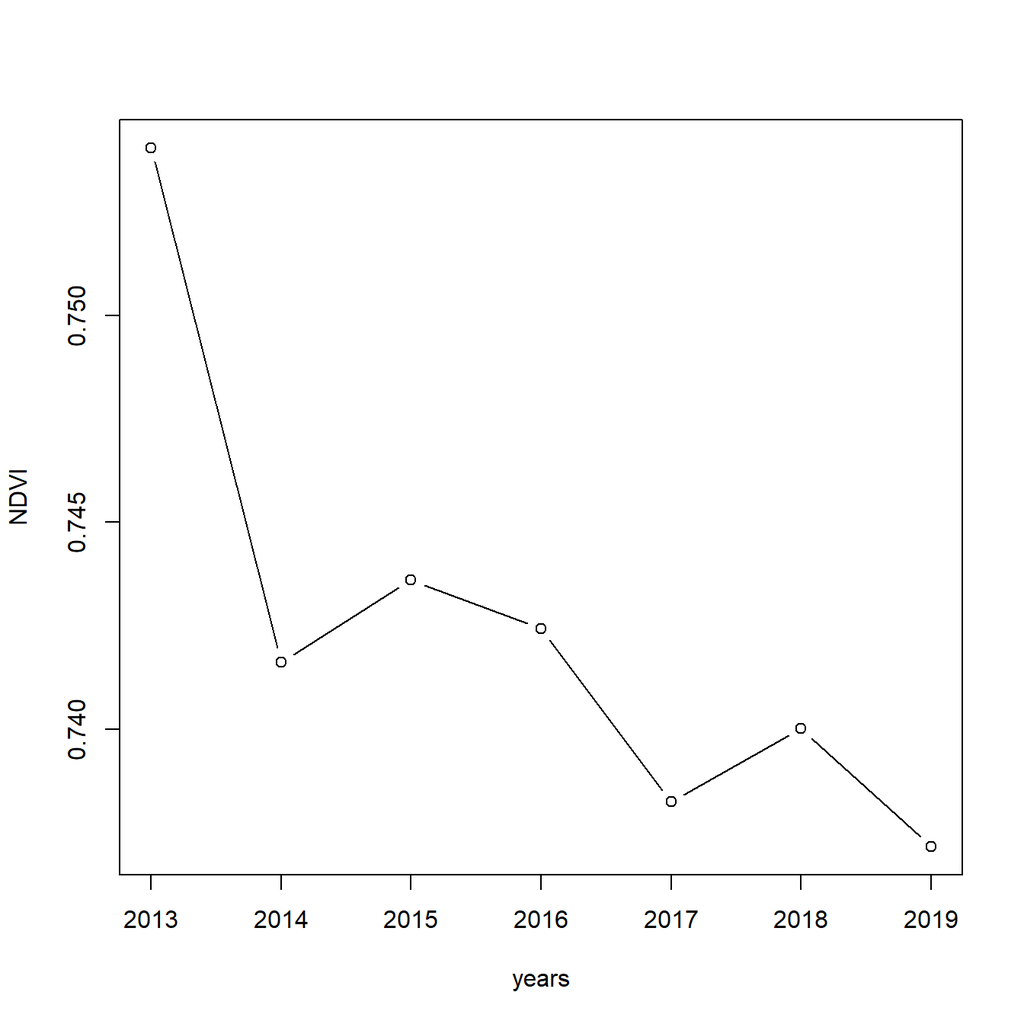

*Figure 10. NDVI mean per image*

# 5 Discussion/Conclusion

The interpolation technique is very basic and purely temporal. To perform optimal predictions, one must incorporate the joint spatio-temporal dependence structure (Wikle, Zammit-Mangion, and Cressie 2019).

Additionally, the models are based on just one index. Even though the Kappa values showed that it is possible to classify between forest and non-forest, more predictors that incorporate for example the texture would increase the model performance.

Ground truth reference data would amplify the reliability of the model because visual interpretation is more subjective. Nevertheless, the forest and non-forest areas seem to be good separable by looking at the true color composites.

It is debatable if comparing two images is sufficient to identify deforestation. A better approach could be to take more past images into account and just classify the non-forest pixels of images as deforested that have been forest in each past image.

Nonetheless the goal of this report was to compare the woodiness index with the NDVI and even if the resulting predictions of deforestation have some limitations, the limitations affect both indices. Ultimately, this report showed that the woodiness index performed inferior to the NDVI index in classifying forest. The NDVI model has an almost perfect agreement indicating its suitability to classify forests. The deforestation based on the NDVI seems to be more plausible, because the patches have a bigger size and are located at accessible areas (e.g. next to the river at the bottom right of the 2014 image). The woodiness index can be added as an additional predictor but should not be the only predictor to build a forest classification model.

# 6 References

Appel, Marius, and Edzer Pebesma. 2019. “On-Demand Processing of Data Cubes from Satellite Image Collections with the Gdalcubes Library.” *Data* 4 (3): 92. https://doi.org/10.3390/data4030092.

Appelhans, Tim, Florian Detsch, Christoph Reudenbach, and Stefan Woellauer. 2020. “Mapview: Interactive Viewing of Spatial Data in R.” https://github.com/r-spatial/mapview.

Bache, Stefan Milton, and Hadley Wickham. 2020. “Magrittr: A Forward-Pipe Operator for R.” https://CRAN.R-project.org/package=magrittr.

Butler, Rhett A. n.d. “Calculating Deforestation Figures for the Amazon.” https://rainforests.mongabay.com/amazon/deforestation_calculations.html.

Cabrera, Derek, James T. Mandel, Jason P. Andras, and Marie L. Nydam. 2008. “What Is the Crisis? Defining and Prioritizing the World’s Most Pressing Problems.” *Frontiers in Ecology and the Environment* 6 (9): 469–75. https://doi.org/10.1890/070185.

Cohen, Jacob. 1960. “A Coefficient of Agreement for Nominal Scales.” *Educational and Psychological Measurement* 20 (1): 37–46. https://doi.org/10.1177/001316446002000104.

Cook, Kerry H., and Edward K. Vizy. 2008. “Effects of Twenty-First-Century Climate Change on the Amazon Rain Forest.” *Journal of Climate* 21 (3): 542–60. https://doi.org/10.1175/2007jcli1838.1.

de Vries, Ben, Jan Verbesselt, Lammert Kooistra, and Martin Herold. 2013. *Detecting Tropical Deforestation and Forest Degradation at High Temporal Resolution in Support of Redd+ Mrv*. ESA Living Planet Symposiumur - Https://Library.wur.nl/Webquery/Wurpubs/447962.

Finer, Matt, Sidney Novoa, Mikaela J. Weisse, Rachael Petersen, Joseph Mascaro, Tamia Souto, Forest Stearns, and Raúl García Martinez. 2018. “Combating Deforestation: From Satellite to Intervention.” *Science* 360 (6395): 1303–5. https://doi.org/10.1126/science.aat1203.

Hojas-Gascon, L., A. Belward, H. Eva, G. Ceccherini, O. Hagolle, J. Garcia, and P. Cerutti. 2015. “Potential Improvement for Forest Cover and Forest Degradation Mapping with the Forthcoming Sentinel-2 Program.” *ISPRS - International Archives of the Photogrammetry, Remote Sensing and Spatial Information Sciences* XL-7/W3: 417–23. https://doi.org/10.5194/isprsarchives-xl-7-w3-417-2015.

Jeffrey A. Ryan, and Joshua M. Ulrich. 2020. “Xts: EXtensible Time Series.” https://CRAN.R-project.org/package=xts.

King, David, Daniel Schrag, Zhou Dadi, Qi Ye, and Arunabha Ghosh. 2017. “Climate Change: A Risk Assessment.”

Kuhn, Max. 2020. “Caret: Classification and Regression Training.” https://CRAN.R-project.org/package=caret.

Landis, J. Richard, and Gary G. Koch. 1977. “The Measurement of Observer Agreement for Categorical Data.” *Biometrics* 33 (1): 159. https://doi.org/10.2307/2529310.

Lehmann, Eric A., Jeremy F. Wallace, Peter A. Caccetta, Suzanne L. Furby, and Katherine Zdunic. 2013. “Forest Cover Trends from Time Series Landsat Data for the Australian Continent.” *International Journal of Applied Earth Observation and Geoinformation* 21: 453–62. https://doi.org/10.1016/j.jag.2012.06.005.

Lenton, Timothy M., Hermann Held, Elmar Kriegler, Jim W. Hall, Wolfgang Lucht, Stefan Rahmstorf, and Hans Joachim Schellnhuber. 2008. “Tipping Elements in the Earth’s Climate System.” *Proceedings of the National Academy of Sciences* 105 (6): 1786–93. https://doi.org/10.1073/pnas.0705414105.

Lovejoy, Thomas E., and Carlos Nobre. 2019. “Amazon Tipping Point: Last Chance for Action.” *Science Advances* 5 (12): eaba2949. https://doi.org/10.1126/sciadv.aba2949.

Malhi, Yadvinder, J. Timmons Roberts, Richard A. Betts, Timothy J. Killeen, Wenhong Li, and Carlos A. Nobre. 2008. “Climate Change, Deforestation, and the Fate of the Amazon.” *Science* 319 (5860): 169–72. https://doi.org/10.1126/science.1146961.

Meyer, Hanna. 2021. “CAST: ’Caret’ Applications for Spatial-Temporal Models.” https://CRAN.R-project.org/package=CAST.

Mitchell, Anthea L., Ake Rosenqvist, and Brice Mora. 2017. “Current Remote Sensing Approaches to Monitoring Forest Degradation in Support of Countries Measurement, Reporting and Verification (Mrv) Systems for Redd.” *Carbon Balance and Management* 12 (1): 9. https://doi.org/10.1186/s13021-017-0078-9.

Pebesma, Edzer. 2021a. “St2.Rmd.” GitHub. https://github.com/edzer/astd/blob/master/st2.Rmd.

———. 2021b. “Stars: Spatiotemporal Arrays, Raster and Vector Data Cubes.”

———. 2021c. “St.Rmd.” GitHub. https://github.com/edzer/astd/blob/master/st.Rmd.

QGIS Development Team. 2021. “QGIS Geographic Information System.” https://www.qgis.org.

R Core Team. 2020. “R: A Language and Environment for Statistical Computing.” Vienna, Austria: R Foundation for Statistical Computing. https://www.R-project.org/.

Rogelj, Joeri, Michel den Elzen, Niklas Höhne, Taryn Fransen, Hanna Fekete, Harald Winkler, Roberto Schaeffer, Fu Sha, Keywan Riahi, and Malte Meinshausen. 2016. “Paris Agreement Climate Proposals Need a Boost to Keep Warming Well Below 2 °C.” *Nature* 534 (7609): 631–39. https://doi.org/10.1038/nature18307.

Spruce, Joseph P., Steven Sader, Robert E. Ryan, James Smoot, Philip Kuper, Kenton Ross, Donald Prados, Jeffrey Russell, Gerald Gasser, and Rodney McKellip. 2011. “Assessment of Modis Ndvi Time Series Data Products for Detecting Forest Defoliation by Gypsy Moth Outbreaks.” *Remote Sensing of Environment* 115 (2): 427–37. https://doi.org/10.1016/j.rse.2010.09.013.

Wikle, Christopher K., Andrew Zammit-Mangion, and Noel Cressie. 2019. *Spatio-Temporal Statistics with R*. Chapman and Hall/Crc the R Ser. Milton: Chapman and Hall/CRC.

Zeng, Ning, Robert E. Dickinson, and Xubin Zeng. 1996. “Climatic Impact of Amazon Deforestation—a Mechanistic Model Study.” *Journal of Climate* 9 (4): 859–83. https://doi.org/10.1175/1520-0442(1996)009{\textless}0859:cioadm{\textgreater}2.0.co;2.

# 7 Appendices

## 7.1 Used software

All plots were created, and computations were done using QGIS 3.10.4 (QGIS Development Team 2021) and R 4.0.3 (R Core Team 2020) with the following packages:

- *caret* 6.0-86 (Kuhn 2020)
- *CAST* 0.5.0 (Meyer 2021)
- *gdalcubes* 0.3.1 (Appel and Pebesma 2019)
- *magrittr* 2.0.1 (Bache and Wickham 2020)
- *mapview* 2.9.4 (Appelhans et al. 2020)
- *stars* 0.5-2 (Pebesma 2021b)
- *xts* 0.12.1 (Jeffrey A. Ryan and Joshua M. Ulrich 2020)